# Biogas cleaning for SOFC applications - costs and performance parameters form the literature

This notebook aims to explicitly show how data was gathered and handeled for the identification of key engineering parameters.

```python
import numpy as np
import pandas as pd
from matplotlib import pyplot as plt
import matplotlib

%matplotlib inline

#np.set_printoptions(precision=3, suppress  = True)
```

## Economic considerations

The operating cost is a significant part of the total cost of the biogas cleaning process. It is therfore useful to annualize the investment cost in order to arrive to the total anual cost or TOTEX to be able to accuratly compare each scenario.

```python
# Annualization factor tau
i = 0.025 # 2.5% interest rate
n = 20 # years of explooitation 1
Tau = (i*(1+i)**n)/((1+i)**n - 1)
# SOurce: from the paper by S. Giarola 2018
```

```python
# list of reference and their respective marker
paper = [['Trendzewich 2013','^'], ['Arespacochaga 2014','o'], ['Giarola 2018', 'x'], ['Work Group 2','s'], ['Tjaden 2014', '+']]
# Key Parameters to be associated with each paper
# N.b. q refers to energy flow, v refers to gas flow rate
TOTEX_q = [[],[],[],[]]
TOTEX_v = [[],[],[],[]]
CAPEX_q = [[],[],[],[]]
CAPEX_v = [[],[],[],[]]
OPEX_q = [[],[],[],[]]
OPEX_v = [[],[],[],[]]
Size_q = [[],[],[],[]]
Size_v = [[],[],[],[]]
Accuracy = [[],[],[],[]]
Perf = [[],[],[]]
# Toggle save figures
save = False
```

```python
# Some data from other sources used multiple times
LHV_CH4v = 32.573/3.6 #kWh/m^3
# Source: DOI 10.1016/S0360-3199(00)00061-6
```

```python
# Assumptions in the context of the W2W project

# SOFC electric effciency LHV based
SOFC_eff_w2w = 0.6

# Biogas volumetric methane fraction on average (MSW, Farm, Land fill)
f_CH4_w2w = 0.56
# Source: PSI’s contributions: Waste2Watts WP1.2

# Capacity Factor
cap_w2w = 0.9 #[-]
```

```python
# functions
def write_EX(inv, op, S, i, unit):
    if unit == 'energy':
        # in EUR/kW-LHV/year
        TOTEX_q[i] = Tau*inv + op
        # in EUR/kW-LHV
        CAPEX_q[i] = inv
        # in EUR/kW-LHV/year
        OPEX_q[i] = op
        # in kW-LHV
        Size_q[i] = S
    else:
        # in EUR/m^3/h/year
        TOTEX_v[i] = Tau*inv + op
        # in EUR/m^3/h
        CAPEX_v[i] = inv
        # in EUR/m^3/h/year
        OPEX_v[i] = op
        # in m^3/h
        Size_v[i] = S
def print_results(inv,  op, S, unit):
    if unit == 'energy':
        print('Function of energy flow in kW-LHV of biogas:')
    else:
        print('Function of volume flow in m^3/h of biogas:')

    print('investment cost: ', ['{:.2f}'.format(i) for i in inv])
    print('operating cost: ', ['{:.2f}'.format(i) for i in op])
    print('size: ', ['{:.2f}'.format(i) for i in S])
```

## 1. A.A. Trendewicz 2013

**Title** : Techno-economic analysis of solid oxide fuel cell-based combined heat and power systems for biogas utilization at wastewater treatment facilities

**Authors** : A.A. Trendewicz, R.J. Braun

**Year of publication** : 2013

**Region of study** : United States

**Relevant summary** : Techno-economic analysis of wastewater derived biogas exploitation using a SOFC. The process is modeled in Aspen Plus. The cleaning process cost is based on biogas conditioning for MCFC applications and includes water removal, H2S removal down to 2.82mg/m^3 and siloxane removal down to 2.82mg/m^3. Comparing three scenarios producing 330kW, 1.53MW and 6.14MW of electricity

### Raw data from the present paper

```python
# Unit Size (small, medium, large)
S_q = np.array([640, 2970, 11920]) #[kW-LHV] net input
# Methane volume fraction in biogas
f_CH4 = 0.566 #[-]
# Capacity Factor
cap = 0.9 #[-]
# Pressure drop
Dp = 10 #[kPa]
# Investment Cost
IC = np.array([355,1908,3825]) #[kUSD of 2011]
# Maintenance Cost
# ! for the entire system, i.e. for the reformer, afterburner and cleaning
OC_spec = np.array([0.016, 0.012, 0.009]) #[USD/kWh]
# Cost uncertainty for a cost estimation analysis
UC = 0.3 #[+ or -]
```

### Data from other sources

```python
# Economics
CEPCI_2019 = 619.2 # Preliminary value for january 2019
CEPCI_ref = 585.7 # value for 2011
Exchange_Rate = 1.239846 #[USD/EUR] average over the 10 last years
# source : https://www.ofx.com/en-au/forex-news/historical-exchange-rates/yearly-average-rates/

# Currency Conversion Factor
C = (CEPCI_2019/CEPCI_ref)/Exchange_Rate


# The fraction of the maintenance cost attributed to the cleaning process
f_OC_cleaning = 0.4 #[-]
# Source: https://eere-exchange.energy.gov/FileContent.aspx?FileID=3352b903-892a-4787-a4d6-67bf53da7c6a
# page five, for a MCFC plant, cleanup OPEX is 20-40% of total OPEX
```

### Unit transformation

```python
# paper index
i = 0

# annual maintenance cost
OC = OC_spec*f_OC_cleaning*S_q*cap*8760 # [USD/year]

# Unit Size (small, medium, large)
S_v = S_q/(LHV_CH4v*f_CH4) # [m^3/h] nominal biogas flow

# Function of energy flow
u = 'energy'
S = S_q
inv = C*1000*np.divide(IC, S) #[EUR/kW-LHV]
op = C*np.divide(OC, S) #[EUR/kW-LHV/year]

write_EX(inv, op, S, i, u)
print_results(inv,  op, S, u)


# Function of volume flow
u = 'volume'
S = S_v
inv = C*1000*np.divide(IC, S) #[EUR/m^3/h]
op = C*np.divide(OC, S) #[EUR/m^3/h/year]

write_EX(inv, op, S, i, u)
print_results(inv,  op, S, u)

Perf[i] = Dp

Accuracy[i] = ['green','grey', 'grey']
```

```
Function of energy flow in kW-LHV of biogas:
investment cost:  ['472.97', '547.78', '273.62']
operating cost:  ['43.02', '32.27', '24.20']
size:  ['640.00', '2970.00', '11920.00']
Function of volume flow in m^3/h of biogas:
investment cost:  ['2422.19', '2805.31', '1401.25']
operating cost:  ['220.34', '165.25', '123.94']
size:  ['124.97', '579.94', '2327.58']
```

## 2. N. de Arespacochaga 2014

**Title** : Biogas deep clean-up based on adsorption technologies for Solid Oxide Fuel Cell applications

**Authors** : N. de Arespacochaga, C. Valderrama, C. Mesa, L. Bouchy, J.L. Cortina

**Year of publication** : 2014

**Region of study** : Spain

**Relevant summary** : Installation of a small scale biogas cleaning unit for SOFC applications, downstream of an anaerobic digester in a WWTP in Spain. The set-up is (i) a regenerable iron-based adsorbent unit to remove H2S, (ii) a biogas drying unit to remove moisture and (iii) an activated carbon unit to remove the remaining trace components (siloxanes, linear and aromatic hydrocarbons). H2S is removed to below 0.5ppm (average 0.1ppm) and Siloxanes, Linear HC and aromatic HC to 1.4-0 ppb. The experiment was conducted for 10m^3 biogas/h for 3600 hours and and economic evaluation, using a scaling factor, predicted the cost for a biogas cleaning process with a though-ut of 190m^3/h. Results for three scenarios are presented: (A) no pre-treatment in the AD. (B) some pre-treatment using bio-trickling. (C) the pre-treatment is optimized to reach 200ppm of solfure in the biogas. Costs for all scenarios are presented at both scales.

### Raw data from the present paper

```python
# Unit Size (small, medium)
S_v = np.array([10, 190]) #[Nm^3/h]
# biogas CH4 fraction (at 30C adn 30mbar(g))
f_CH4 = (0.551 + 0.578)/2 #[-]
# Investment Cost
IC = np.array([350, 350, 226]) #[kEUR of 2013]
# Operating Cost
OC = np.array([26.2, 44.7, 136.5]) #[kEUR/year]
# electricity consumption of cleaning units (scrubber + polisher)
E_filter = 6600 #kWh/year
E_chill = 6400 #kWh/year
# Cost uncertainty for a demonstration plant
UC = 0.1 #[+ or -]
```

### Data from other sources

```python
# Thermodynamics
LHV_CH4v = 32.573/3.6 #kWh/m^3
# Source: DOI 10.1016/S0360-3199(00)00061-6

# Economics
CEPCI_2019 = 619.2 # Preliminary value for january 2019
CEPCI_ref = 584.6 # value for 2013
# source : https://www.ofx.com/en-au/forex-news/historical-exchange-rates/yearly-average-rates/

# Currency Conversion Factor
C = (CEPCI_2019/CEPCI_ref)
```

### Unit transformation

```python
# paper index
i = 1

# Unit Size (small, medium)
S_q = S_v*LHV_CH4v*f_CH4 # [kW-LHV] nominal biogas flow

# Function of energy flow
u = 'energy'
S = S_q

scale_f_inv = (S_v[0]/S_v[1])**0.6
inv = np.append(IC*scale_f_inv/S[0], IC/S[1])*C*1000  #[EUR/kW-LHV]
scale_f_op = (S_v[0]/S_v[1])
op = np.append(OC*scale_f_op/S[0], OC/S[1])*C*1000  #[EUR/kW-LHV/year]

S = np.repeat(S_q,3, axis=0)
write_EX(inv, op, S, i, 'energy')


# Function of volume flow
u = 'volume'
S = S_v

scale_f_inv = (S_v[0]/S_v[1])**0.6
inv = np.append(IC*scale_f_inv/S[0], IC/S[1])*C*1000  #[EUR/m^3/h]
scale_f_op = (S_v[0]/S_v[1])
op = np.append(OC*scale_f_op/S[0], OC/S[1])*C*1000  #[EUR/m^3/h/year]

S = np.repeat(S_v,3, axis=0)
write_EX(inv, op, S, i, 'volume')
print_results(inv,  op, S, u)

Accuracy[i] = ['green','grey','grey','green','grey','grey']
```

```
Function of volume flow in m^3/h of biogas:
investment cost:  ['6335.60', '6335.60', '4090.99', '1951.13', '1951.13', '1259.87']
operating cost:  ['146.06', '249.19', '760.94', '146.06', '249.19', '760.94']
size:  ['10.00', '10.00', '10.00', '190.00', '190.00', '190.00']
```

### Pressure drop Estimation

```python
S_v[1] = 190 # m^3/h
E_filter = 6600 # kWh/year
W_dot = E_filter/(cap_w2w*8760) #kW
V_dot = S_v[1]/3600 #m^3/s
Cp_biogas = 1.6
gamma = 1.2 #TBD
density_biogas = 1.15 # kg/m^3
T_1 = 60 + 273 # K
eff_isentropic = 0.5 #(from paper 4)
P_1 = 101325 # Pa

DT = (W_dot*eff_isentropic)/(V_dot*density_biogas)

DP = P_1*(((T_1+DT)/T_1)**(gamma/(gamma-1))-1)/1000 # in kPa

print('Temperature rise in the compressor: ', DT.round(3) ,' C')
print('Pressure ruse in the compressor: ', DP.round(3) ,' kPa')

Perf[i] = DP
```

```
Temperature rise in the compressor:  6.896  C
Pressure ruse in the compressor:  13.261  kPa
```

```python
# Exact calculations
S_v[1] = 190 # m^3/h
E_filter = 6600 # kWh/year
W_dot = E_filter/(cap_w2w*8760) #kW
V_dot = S_v[1]/3600 #m^3/s

# gas volume fraction
f_CH4 = (0.551+0.578)/2
f_CO2 = (0.285+0.325)/2
f_N2 = 1 - f_CH4 - f_CO2

#f_CH4 = 0.6
#f_CO2 = 0.4
#f_N2 = 0

# all values from nist webbook at 60°C
density = f_CH4*0.5798 + f_CO2*1.5943 + f_N2*1.0113
C_p = f_CH4*2.3209 + f_CO2*0.88373 + f_N2*1.0418
C_v = f_CH4*1.7990 + f_CO2*0.69171 + f_N2*0.74392
gamma = C_p/C_v

DT = W_dot/(V_dot*density*C_p)
DP = P_1*(((T_1+DT)/T_1)**(gamma/(gamma-1))-1)/1000
DT, DP, f_CH4, f_CO2, f_N2
```

```
(9.777843887868936, 13.680095981833595, 0.5645, 0.305, 0.1305)
```

## 3. S. Giarola 2018

**Title** : Techno-economic assessment of biogas-fed solid oxide fuel cell combined heat and power system at industrial scale

**Authors** : Sara Giarola, Ornella Forte, Andrea Lanzini, Marta Gandiglio, Massimo Santarelli, Adam Hawkes

**Year of publication** : 2018

**Region of study** : EU

**Relevant summary** : Techno-economic evaluation of the retrofitting of a sud-MW WWTP, to accomodate an AD, biogas holder, biogas cleaning system in two parts and SOFC. The cleaning system after the holder is made of a blower, a dryer, S and Si removal with inline sampling another dryer and a polisher step followed by a compressor. Net SOFC capacity is 175kw electric. The cleaning layout is based on the EU-project 'DEMOSOFC'.

Three scenarios are presented for the costing of the cleanup system: (A) current manufacturing volume of 100 units. (B) short-term manufacturing volume of 1'000 units. (C) Target manufacturing volume of 10'000.

### Raw data from the present paper

```python
# Net electric capacity
Size = 174.9 #[kW-el]
# cleaning CAPEX for scenarios A, B, C
IC = np.array([917, 459, 183]) #[EUR/kW]
# cleaning OPEX for scenarios A, B, C
OC = np.array([76, 57, 38]) #[EUR/kW/year]
# biogas energy density
CH4_v_spec = 21501/3600 #kWh/m^3
# SOFC electric effciency LHV based
SOFC_eff = 0.6
```

### Data from other sources

```python
# Economics
CEPCI_2019 = 619.2 # Preliminary value for january 2019
CEPCI_ref = 603.1 # value for 2018
# source : https://www.ofx.com/en-au/forex-news/historical-exchange-rates/yearly-average-rates/

# Currency Conversion Factor
C = (CEPCI_2019/CEPCI_ref)
```

### Unit transformation

```python
# paper index
i = 2

# Unit size
#eff [kw/kw-LWH]
S_q = Size/SOFC_eff #[kW-LHV]
S_v = (S_q/CH4_v_spec)/f_CH4_w2w #[m^3/h]

# Function of energy flow
u = 'energy'
S = S_q

inv = IC*C*SOFC_eff  #[EUR/kW-LHV]
op = OC*C*SOFC_eff  #[EUR/kW-LHV/year]

S = np.repeat(S_q,3, axis=0)
write_EX(inv, op, S, i, u)
print_results(inv,  op, S, u)



# Function of volume flow
u = 'volume'
S = S_v

inv = IC*C*SOFC_eff*CH4_v_spec*f_CH4_w2w  #[EUR/m^3/h]
op = OC*C*SOFC_eff*CH4_v_spec*f_CH4_w2w  #[EUR/m^3/h/year]

S = np.repeat(S_v,3, axis=0)
write_EX(inv, op, S, i, u)
print_results(inv,  op, S, u)

Perf[i] = Dp
Accuracy[i] = ['green','grey','grey']
```

```
Function of energy flow in kW-LHV of biogas:
investment cost:  ['564.89', '282.75', '112.73']
operating cost:  ['46.82', '35.11', '23.41']
size:  ['291.50', '291.50', '291.50']
Function of volume flow in m^3/h of biogas:
investment cost:  ['1889.32', '945.69', '377.04']
operating cost:  ['156.59', '117.44', '78.29']
size:  ['87.16', '87.16', '87.16']
```

## 4. B. Tjaden 2014

**Title** : Small-Scale Biogas-SOFC Plant: Technical Analysis and Assessment of Different Fuel Reforming Options

**Authors** : B. Tjaden, M. Gandiglio, A. Lanzini, M. Santarelli, and M. Järvinen

**Year of publication** : 2014

**Region of study** : EU

**Relevant summary** : This paper investigates simulation results of the thermodynamic performance of a 25 kWel small-scale solid oxide fuel cell model fuelled with biogas

```python
# Pressure drop in cleaning section
Perf[2] = 15 # kPa
Size_p4 = 25 # kW
```

## 5. Work Group 2 results

**Title** : GAS CLEAN‐UP FOR FUEL CELL APPLICATIONS WORKSHOP (referennce report)

**Organizers** : Argonne National Laboratory

**Year of publication** : 2014

**Region of study** : United States

**Relevant summary** : Workshop held on the subject of gas cleaning for fuel cell applications, with predicted cost of investment and maintenant relative to size and volume manufactured.

**Link** : https://eere-exchange.energy.gov/FileContent.aspx?FileID=3352b903-892a-4787-a4d6-67bf53da7c6a

### Raw data from the present paper

```python
# Unit Size (small)
S_v = np.array([72187/(cap_w2w*8760)]) #[Nm^3/h] nominal biogas flow
# Investment Cost (originally per kw-electric)
IC = np.array([1000])*25 #[EUR of 2019]
# Operating Cost
OC = np.array([4609]) #[EUR/year]
```

### Unit transformation

```python
# paper index
i = 3

# Unit Size (small)
S_q = S_v*LHV_CH4v*f_CH4_w2w # [kW-LHV] nominal biogas flow

# Function of energy flow
u = 'energy'
S = S_q
inv = IC/S_q #[EUR/kW-LHV]
op = OC/S #[EUR/kW-LHV/year]

write_EX(inv, op, S, i, u)
print_results(inv,  op, S, u)

# Function of volume flow
u = 'volume'
S = S_v
inv = IC/S #[EUR/kW-LHV]
op = OC/S #[EUR/kW-LHV/year]

write_EX(inv, op, S, i, u)
print_results(inv,  op, S, u)

Accuracy[i] = ['blue']
```

```
Function of energy flow in kW-LHV of biogas:
investment cost:  ['538.87']
operating cost:  ['99.35']
size:  ['46.39']
Function of volume flow in m^3/h of biogas:
investment cost:  ['2730.41']
operating cost:  ['503.38']
size:  ['9.16']
```

## Result Display

### Total costs relative to size

Only the datapoint for the smallest power output from paper 1 is shown.

```python
# Switch functions for the different graphical representations
def switch_kind(kind):
    switcher={
        'TOTEX': 'Total Annual Costs',
        'CAPEX': 'Investment Costs',
        'OPEX': 'Operating Costs',
    }
    return switcher.get(kind, "Invalid kind")

def switch_unit(unit):
    switcher={
        'energy': ['Energy Flow', 'kW-LHV'],
        'volume': ['Volume Flow', ' $m^3$/ h '],
    }
    return switcher.get(unit, "Invalid unit")
```

```python
# create an empty list to put fit results in
fit_results = []

# plot a fitting law of coefficient fit for a given unit (based on paper 2)
def plt_fit_law(fit, Size, Cost, unit, *args):

    # Size of the W2W installation according to units
    if unit == 'energy':
        w2w = 25/SOFC_eff_w2w # in kW-LHV
    else:
        w2w = 25/(SOFC_eff_w2w*LHV_CH4v*f_CH4_w2w) # in m^3/h


    # fit to paper number 2
    f = 1

    # Draw the appropriate scaling law according to the value of fit
    if len(args) == 0:
        C = Cost[f][0]
        print(C)
    else:
        C = mean


    q = np.arange(1,12000,1)
    y = (C*Size[f][0])*(q/Size[f][0])**fit
    y_w2w = (C*Size[f][0])*(w2w/Size[f][0])**fit/w2w
    plt.plot(q, y/q, c = 'skyblue', zorder=0, label='scaling law')
    plt.plot(q, 1.3*y/q, q, 0.7*y/q, c ='skyblue', linestyle ='dashed')
    plt.scatter(w2w, y_w2w, c = 'orange', label='est. value for W2W', marker = '*', s = 200)

    print('fit results: size: {:.2f} costs: {:.2f}'.format(w2w, y_w2w))
    fit_results.extend([w2w, y_w2w])
```

```python
def plt_scatter_data(Size, Cost, Accuracy, paper, tight, kind, unit, fit):
    fig, ax = plt.subplots()
    # scatter plot of paper data
    for i in np.arange(len(Size)):
        ax.scatter(Size[i], Cost[i], c = Accuracy[i], label = paper[i][0], marker = paper[i][1])

    # plot the given scaling law
    if fit != 0:
        plt_fit_law(fit, Size, Cost, unit)

    # reduce size to the scale of focus
    if tight:
        S = [i for s in Size for i in s]
        S.sort()
        plt.xlim(0, S[-3]*1.1)

        C = [i for s in Cost for i in s]
        C.sort()
        plt.ylim(0, C[-1]*1.25)

    # create a plot title and axis names according to kind and unit
    u = switch_unit(unit)
    k = switch_kind(kind)

    Title = ' '.join([k, 'vs', u[0]])
    Xlabel = '{} [ {} ]'.format(u[0], u[1])
    if kind == 'CAPEX':
        Ylabel = '{} [ EUR / {} ]'.format(kind, u[1])
    else:
        Ylabel = '{} [ EUR / {} / year ]'.format(kind, u[1])

    plt.title(Title)
    plt.xlabel(Xlabel)
    plt.ylabel(Ylabel)
    ax.grid(True, linestyle='-', which='major', color='lightgrey',alpha=0.5)

    plt.legend(loc = 'upper center')

    file_name = '{}_vs_size_{}.pdf'.format(kind, unit)
    if save:
        plt.savefig(file_name)
        print('figure saved as', file_name)
```

## Costs as a function of volume flow in m$^3$/h

```
552.4669445044215
fit results: size: 8.22 costs: 580.16
```

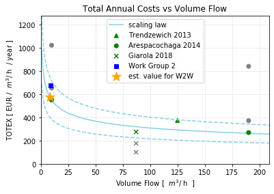

```python
# Total costs as a function of volume flow
fit = 0.75
tight = True
kind = 'TOTEX'
unit = 'volume'
plt_scatter_data(Size_v, TOTEX_v, Accuracy, paper, tight, kind, unit, fit)

plt.savefig('TOTEX_vs_size_volume_default.pdf')

plt.show()
```

```
6335.603943163315
fit results: size: 8.22 costs: 6851.25
```

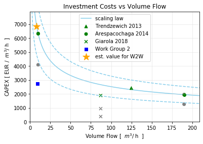

```python
# Investment costs as a function of volume flow
fit = 0.6
tight = True
kind = 'CAPEX'
unit = 'volume'
plt_scatter_data(Size_v, CAPEX_v, Accuracy, paper, tight, kind, unit, fit)
# color correction for the CAPEX plot of paper 2
plt.scatter(Size_v[1][::3], CAPEX_v[1][::3], c = Accuracy[1][0], marker = paper[1][1])
plt.savefig('CAPEX_vs_size_volume.pdf')
plt.show()
```

```
146.05614275167903
fit results: size: 8.22 costs: 146.06
```

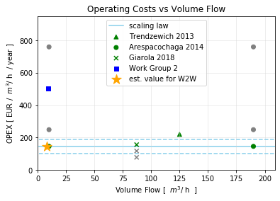

```python
# Defaulf fit: Operating costs as a function of volume flow
fit = 1
tight = True
kind = 'OPEX'
unit = 'volume'
plt_scatter_data(Size_v, OPEX_v, Accuracy, paper, tight, kind, unit, fit)
plt.show()
```

```
fit results: size: 8.22 costs: 174.33
```

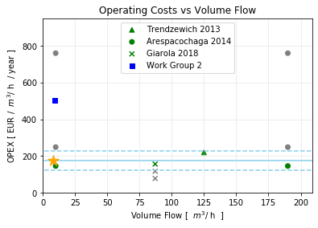

```python
# Better fit: Operating costs as a function of volume flow
fit = 0
tight = True
kind = 'OPEX'
unit = 'volume'
plt_scatter_data(Size_v, OPEX_v, Accuracy, paper, tight, kind, unit, fit)

# Corrected fit to the average OPEX of the three most accurate opex values
fit = 1
mean = np.mean([OPEX_v[0][0], OPEX_v[1][0], OPEX_v[2][0]])

plt_fit_law(fit, Size_v, OPEX_v, unit, mean)

plt.savefig('OPEX_vs_size_volume.pdf')

plt.show()
```

```
fit results: size: 8.22 costs: 609.84
```

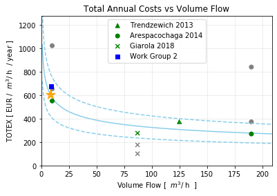

```python
# Better fit: Total costs as a function of volume flow
fit = 0
tight = True
kind = 'TOTEX'
unit = 'volume'
plt_scatter_data(Size_v, TOTEX_v, Accuracy, paper, tight, kind, unit, fit)

# Corrected fit to the average OPEX of the three most accurate opex values
fit = 0.75
mean = (np.mean([OPEX_v[0][0], OPEX_v[1][0], OPEX_v[2][0]]) - OPEX_v[1][0]) + TOTEX_v[1][0]

plt_fit_law(fit, Size_v, OPEX_v, unit, mean)

plt.savefig('TOTEX_vs_size_volume_better.pdf')

plt.show()
```

## Costs as a function of energy flow kW-LHV

```
108.16508438161355
fit results: size: 41.67 costs: 113.81
```

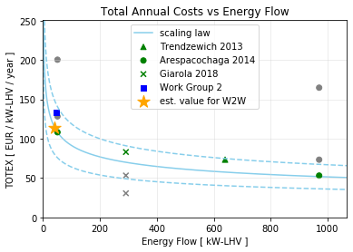

```python
# Total costs as a function of energy flow
fit = 0.75
tight = True
kind = 'TOTEX'
unit = 'energy'
plt_scatter_data(Size_q, TOTEX_q, Accuracy, paper, tight, kind, unit, fit)

plt.savefig('TOTEX_vs_size_energy_default.pdf')

plt.show()
```

```
1240.4201589571467
fit results: size: 41.67 costs: 1345.68
```

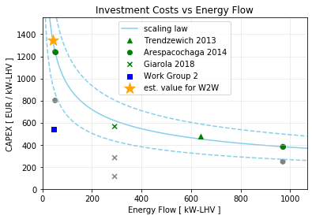

```python
# Investment costs as a function of energy flow
fit = 0.6
tight = True
kind = 'CAPEX'
unit = 'energy'
plt_scatter_data(Size_q, CAPEX_q, Accuracy, paper, tight, kind, unit, fit)

# color correction for the CAPEX plot of paper 2
plt.scatter(Size_q[1][::3], CAPEX_q[1][::3], c = Accuracy[1][0], marker = paper[1][1])

plt.savefig('CAPEX_vs_size_energy.pdf')

plt.show()
```

```
28.59569276015196
fit results: size: 41.67 costs: 28.60
```

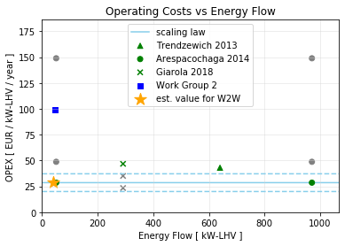

```python
# Defaulf fit: Operating costs as a function of energy flow
fit = 1
tight = True
kind = 'OPEX'
unit = 'energy'
plt_scatter_data(Size_q, OPEX_q, Accuracy, paper, tight, kind, unit, fit)
plt.show()
```

```
fit results: size: 41.67 costs: 39.48
```

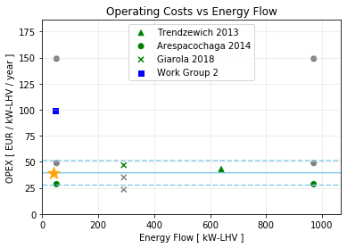

```python
# Better fit: Operating costs as a function of energy flow
fit = 0
tight = True
kind = 'OPEX'
unit = 'energy'
plt_scatter_data(Size_q, OPEX_q, Accuracy, paper, tight, kind, unit, fit)

# Corrected fit to the average OPEX of the three most accurate opex values
fit = 1
mean = np.mean([OPEX_q[0][0], OPEX_q[1][0], OPEX_q[2][0]])

plt_fit_law(fit, Size_q, OPEX_q, unit, mean)

plt.savefig('OPEX_vs_size_energy.pdf')

plt.show()
```

```
fit results: size: 41.67 costs: 125.27
```

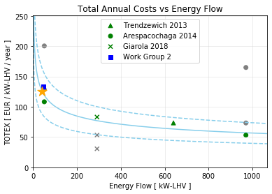

```python
# Better fit: Total costs as a function of energy flow
fit = 0
tight = True
kind = 'TOTEX'
unit = 'energy'
plt_scatter_data(Size_q, TOTEX_q, Accuracy, paper, tight, kind, unit, fit)

# Corrected fit to the average OPEX of the three most accurate opex values
fit = 0.75
mean = (np.mean([OPEX_q[0][0], OPEX_q[1][0], OPEX_q[2][0]]) - OPEX_q[1][0]) + TOTEX_q[1][0]

plt_fit_law(fit, Size_q, OPEX_q, unit, mean)

plt.savefig('TOTEX_vs_size_energy_better.pdf')

plt.show()
```

## Print best values and ranges into a table

```python
def tabulate(cost):
    tab = {}
    for i in range(len(paper) - 1):
        values = cost[i].tolist()
        values = [int(round(j)) for j in values]

        if i == 1:
            tab[paper[i][0] + ' small'] = values[:3]
            tab[paper[i][0] + ' large'] = values[3:]
        else:
            tab.update({paper[i][0]: values})

    return tab
```

```python
Accuracy
```

```
[['green', 'grey', 'grey'],
 ['green', 'grey', 'grey', 'green', 'grey', 'grey'],
 ['green', 'grey', 'grey'],
 ['blue']]
```

```python
tabulate(Size_v)
```

```
{'Trendzewich 2013': [125, 580, 2328],
 'Arespacochaga 2014 small': [10, 10, 10],
 'Arespacochaga 2014 large': [190, 190, 190],
 'Giarola 2018': [87, 87, 87],
 'Work Group 2': [9]}
```

```python
tabulate(CAPEX_v)
```

```
{'Trendzewich 2013': [2422, 2805, 1401],
 'Arespacochaga 2014 small': [6336, 6336, 4091],
 'Arespacochaga 2014 large': [1951, 1951, 1260],
 'Giarola 2018': [1889, 946, 377],
 'Work Group 2': [2730]}
```

```python
tabulate(OPEX_v)
```

```
{'Trendzewich 2013': [220, 165, 124],
 'Arespacochaga 2014 small': [146, 249, 761],
 'Arespacochaga 2014 large': [146, 249, 761],
 'Giarola 2018': [157, 117, 78],
 'Work Group 2': [503]}
```

```python
tabulate(Size_q)
```

```
{'Trendzewich 2013': [640, 2970, 11920],
 'Arespacochaga 2014 small': [51, 51, 51],
 'Arespacochaga 2014 large': [970, 970, 970],
 'Giarola 2018': [292, 292, 292],
 'Work Group 2': [46]}
```

```python
tabulate(CAPEX_q)
```

```
{'Trendzewich 2013': [473, 548, 274],
 'Arespacochaga 2014 small': [1240, 1240, 801],
 'Arespacochaga 2014 large': [382, 382, 247],
 'Giarola 2018': [565, 283, 113],
 'Work Group 2': [539]}
```

```python
tabulate(OPEX_q)
```

```
{'Trendzewich 2013': [43, 32, 24],
 'Arespacochaga 2014 small': [29, 49, 149],
 'Arespacochaga 2014 large': [29, 49, 149],
 'Giarola 2018': [47, 35, 23],
 'Work Group 2': [99]}
```

```python
fit_results[:10]
```

```
[8, 580, 8, 6851, 8, 146, 8, 174, 8, 610]
```

```python
fit_results[10:]
```

```
[42, 114, 42, 1346, 42, 29, 42, 39, 42, 125]
```